Names: Roger Asquith / rsa5249@psu.edu , Jayvian Pettit /jup625@psu.edu

## PART A

Objective: The objective was to bulid the best machine-learning models based on the training set. We plan to predict the target values of the testing set accurately. Success is based on the performance of the testing set and the ability of the model to generalize the information it produces.

# This section allows us to use the testing set to figure out legitimate or illegitimate phishing websites.

# Training model on Testing set with Training set below

```python
from google.colab import files
uploaded = files.upload()
```

Upload widget is only available when the cell has been executed in the current browser session. Please rerun this cell to enable.

```
Saving Phishing_Legitimate_test_student.csv to Phishing_Legitimate_test_student (1).csv
```

```python
from google.colab import files
uploaded = files.upload()
```

Upload widget is only available when the cell has been executed in the current browser session. Please rerun this cell to enable.

```
Saving Phishing_Legitimate_train_missing_data.csv to Phishing_Legitimate_train_missing_data (1).csv
```

```python
import pandas as pd
import numpy as np
df = pd.read_csv('Phishing_Legitimate_train_missing_data.csv', index_col='id', na_values=['',' ','n/a'])
#print(df)
```

```python
import pandas as pd
import numpy as np
df1 = pd.read_csv('Phishing_Legitimate_test_student.csv', index_col='id', na_values=['',' ','n/a'])
#print(df)
```

```python
from re import X
from sklearn.tree import DecisionTreeClassifier
#define a tree model with maximum of two levels. The random state is set at 0 so the same values can be runned everytime we used it.
clf = DecisionTreeClassifier(max_depth=2,random_state=0)
#train the model

features = (['NoHttps', 'IpAddress', 'NumSensitiveWords', 'InsecureForms',
       'AbnormalFormAction', 'PopUpWindow', 'MissingTitle'])
#              X             Y
clf.fit(df[features], df['CLASS_LABEL'])
```

```
DecisionTreeClassifier(max_depth=2, random_state=0)
```

```python
print(df1)
```

```
      NumDots  SubdomainLevel  PathLevel  UrlLength  NumDash  \
id
1           6               1          2         59        0
2           2               1          3         76        4
3           3               1          1         59        0
4           5               1          3         67        0
5           2               0          4         88        3
...       ...             ...        ...        ...      ...
4996        3               0          6         66        1
4997        1               0          5        104       11
4998        1               0          3         74        7
4999        2               1          3         40        0
5000        2               1          2         61        1

      NumDashInHostname  AtSymbol  TildeSymbol  NumUnderscore  NumPercent  \
```

[output cut: 56 more lines]

```python
selected_features = df1[['NoHttps', 'IpAddress', 'NumSensitiveWords', 'InsecureForms', 'AbnormalFormAction', 'PopUpWindow', 'MissingTitle']]

print(selected_features)
```

```
      NoHttps  IpAddress  NumSensitiveWords  InsecureForms  \
id
1           1          0                  1              1
2           1          0                  0              1
3           1          0                  0              0
4           1          0                  0              1
5           1          0                  1              1
...       ...        ...                ...            ...
4996        1          0                  0              1
4997        1          0                  0              1
4998        1          0                  0              1
4999        1          0                  0              1
5000        1          0                  0              0

      AbnormalFormAction  PopUpWindow  MissingTitle
id
1                      0            0             0
2                      1            0             0
3                      0            0             0
4                      0            0             0
5                      0            0             0
...                  ...          ...           ...
4996                   0            0             0
4997                   0            0             0
4998                   0            0             0
4999                   0            0             0
5000                   0            0             0

[5000 rows x 7 columns]
```

```python
print(features) #from training
print(selected_features) #from testing
```

```
['NoHttps', 'IpAddress', 'NumSensitiveWords', 'InsecureForms', 'AbnormalFormAction', 'PopUpWindow', 'MissingTitle']
      NoHttps  IpAddress  NumSensitiveWords  InsecureForms  \
id
1           1          0                  1              1
2           1          0                  0              1
3           1          0                  0              0
4           1          0                  0              1
5           1          0                  1              1
...       ...        ...                ...            ...
4996        1          0                  0              1
4997        1          0                  0              1
4998        1          0                  0              1
4999        1          0                  0              1
5000        1          0                  0              0

      AbnormalFormAction  PopUpWindow  MissingTitle
id
1                      0            0             0
2                      1            0             0
3                      0            0             0
4                      0            0             0
5                      0            0             0
...                  ...          ...           ...
4996                   0            0             0
4997                   0            0             0
4998                   0            0             0
4999                   0            0             0
5000                   0            0             0

[5000 rows x 7 columns]
```

```python
#The features we used to check our testing set:


# Now you can make predictions
selected_features = df1[features] #This line was moved below the fitting process
predictions = clf.predict(selected_features)

df1['Predicted_Class_Label'] = predictions
# Print or use the predictions as needed
print(predictions)

print(df1['Predicted_Class_Label'])
```

```
[1 1 0 ... 1 1 0]
id
1       1
2       1
3       0
4       1
5       1
       ..
4996    1
4997    1
4998    1
4999    1
5000    0
Name: Predicted_Class_Label, Length: 5000, dtype: int64
```

```python
print(df1)
```

```
      NumDots  SubdomainLevel  PathLevel  UrlLength  NumDash  \
id
1           6               1          2         59        0
2           2               1          3         76        4
3           3               1          1         59        0
4           5               1          3         67        0
5           2               0          4         88        3
...       ...             ...        ...        ...      ...
4996        3               0          6         66        1
4997        1               0          5        104       11
4998        1               0          3         74        7
4999        2               1          3         40        0
5000        2               1          2         61        1

      NumDashInHostname  AtSymbol  TildeSymbol  NumUnderscore  NumPercent  \
```

[output cut: 56 more lines]

```python
clf.fit(df[features], df1['Predicted_Class_Label'])
```

```
DecisionTreeClassifier(max_depth=2, random_state=0)
```

Here are the results from each Model testing procedure. We used the Decision Tree, Random Forest, and Single Vector Machine (SVM)

**Decision Tree**

[output not shown]

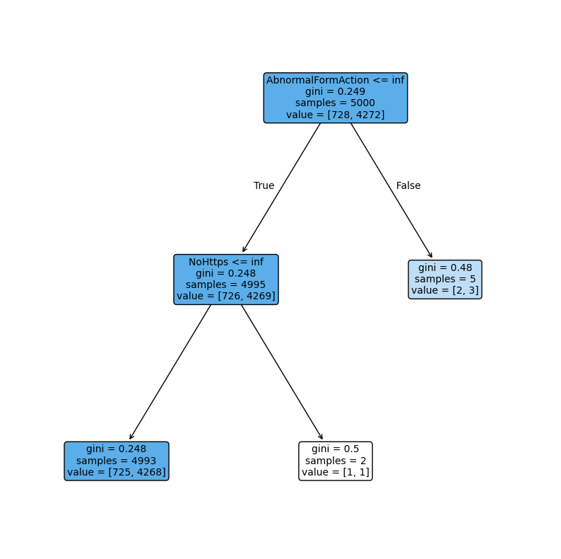

```python
import matplotlib.pyplot as plt
from sklearn import tree
plt.figure(figsize=(10,10))
tree.plot_tree(clf, filled=True, impurity=True, fontsize=10,feature_names=features, rounded=True)
```

Decision findings: There was not alot of branches to this decision tree. This might of affected how accurate our model is.

This code just sets up the features and its importance to the decision tree.

```python
import matplotlib.pyplot as plt
from sklearn.ensemble import RandomForestClassifier
from sklearn.inspection import permutation_importance
from sklearn.model_selection import train_test_split

X = df[features]
y = df1['Predicted_Class_Label']

# Split the data into training and testing sets
# Added this line to split the data
#This code just sets up the features and its importance to the decision tree.

X_train, X_test, y_train, y_test = train_test_split(X, y, test_size=0.2, random_state=2)

rf = RandomForestClassifier(random_state=2)
rf.fit(X_train,y_train)

importances = rf.feature_importances_
feature_importance_df = pd.DataFrame ({'Feature': X.columns, 'Importance': importances}).sort_values(by = 'Importance', ascending=False)
```

**Support Vector Machine (SVM)**

```python
#SVM

# Split the data into training and testing sets
from sklearn.model_selection import train_test_split
from sklearn.impute import SimpleImputer # Import SimpleImputer
X = df[features]
y = df1['Predicted_Class_Label']
X_train, X_test, y_train, y_test = train_test_split(X, y, test_size=0.2, random_state=2) # Added this line to split the data



#normalizing the columns using their min and max values OPTIMIZE SUPPORT VECTOR MACHINE
#SVM work better with normalized data

from sklearn.preprocessing import MinMaxScaler

scaler=MinMaxScaler()

# Use X_train instead of train
normalized_train = X_train.copy()
# Assuming 'selected_features' is the same as 'features'

# Impute missing values before scaling
imputer = SimpleImputer(strategy='mean') # Create an imputer instance
normalized_train[features] = imputer.fit_transform(X_train[features]) # Impute missing values in X_train
normalized_train[features] = scaler.fit_transform(normalized_train[features]) # Scale the data

# Use X_test instead of test
normalized_test = X_test.copy()
normalized_test[features] = imputer.transform(X_test[features]) # Impute missing values in X_test using the trained imputer
normalized_test = scaler.transform(normalized_test[features])

#normalized_train=(train-train.min())/(train.max()-train.min())
#normalized_test=(test-test.min())/(test.max()-test.min())

c_parameters = np.linspace(1, 100, 10, endpoint=True)
print("These are the parameters")
print(c_parameters)
print()

from sklearn import svm
#create a empty base model
base_model = svm.SVC(random_state=0)


#A dictionary data structure is used to indicate which parameters will be tuned and their values
tuned_parameters=[{'C':c_parameters,'kernel':['linear', 'poly', 'rbf']}]
#Grid search

from sklearn.model_selection import GridSearchCV
clf = GridSearchCV(estimator = base_model, param_grid = tuned_parameters, scoring ='roc_auc', cv=5) #optimizing parameters, this will find the best parameters
# Use X_train and y_train instead of normalized_train and train['label']
clf.fit(normalized_train[features],  y_train)
print("This will be the best parameters ")
print(clf.best_params_)
print()


#Sample code part 2:

# Use X_test instead of test
normalized_test = X_test.copy()
normalized_test[features] = scaler.transform(X_test[features])


#Sample code part 3:

#train the final random forest using the whole traing set and the best parameters
svm_best=svm.SVC(**clf.best_params_)
svm_best.fit(normalized_train[features], y_train) # Use y_train
predicted_test=svm_best.predict(normalized_test[features]) # Use normalized_test
print()
print('The testing set report')
# Import classification_report if not already imported
from sklearn.metrics import classification_report
print()
print(classification_report(y_test, predicted_test, labels=[1,0],target_names=['spam','non-spam'])) # Use y_test
```

```
These are the parameters
[  1.  12.  23.  34.  45.  56.  67.  78.  89. 100.]

This will be the best parameters
{'C': 45.0, 'kernel': 'rbf'}


The testing set report

              precision    recall  f1-score   support

        spam       0.84      1.00      0.91       836
    non-spam       0.00      0.00      0.00       164

    accuracy                           0.84      1000
   macro avg       0.42      0.50      0.46      1000
weighted avg       0.70      0.84      0.76      1000
```

Results:

**Random Forest / K Fold Validation**

```python
#Random Forest / K Fold Validation (training)

from sklearn.ensemble import RandomForestClassifier
from sklearn.model_selection import cross_val_score, StratifiedKFold
import numpy as np

X = df[features]
y = df1['Predicted_Class_Label']

rf = RandomForestClassifier(max_depth=18, min_samples_split = 4, n_estimators=100, random_state=1)

kfold = StratifiedKFold(n_splits=5, shuffle=True, random_state=1)

cv_scores = cross_val_score(rf, X, y, cv=kfold, scoring='roc_auc')

print("AUC scores for each fold:", cv_scores)
print('Mean AUC', np.mean(cv_scores))
print('Standard Deviation of AUC:', np.std(cv_scores))
```

```
AUC scores for each fold: [0.48780399 0.47734624 0.49805508 0.48783324 0.51361041]
Mean AUC 0.4929297929396205
Standard Deviation of AUC: 0.012239707564122262
```

Overall the AUC scores prove that the model is underpreforming. We tried many methods to increase the AUC score but to no avail. We tried changing the decision tree classifiers' max depth to several different values such as 4,7,9 and the random values to 2,10,3 and it barely affected the AUC score. Anything below .5 proves that the classifier is poorly trained. The mean being below 0.5 proves that it lacks power and the 0.01 on the standard deviation proves that it folds but the model is poor.

Confusion Matrix

The first two code snippets are used to set up the confusion matrix.

```python
from sklearn.model_selection import train_test_split
#split the dataset as training and testing sets 50/50
#we will use the training to select best paramaters and train to compare final models.
train, test = train_test_split(df1, test_size=0.5, random_state=0)

# Import necessary libraries
from sklearn.ensemble import RandomForestClassifier
from sklearn.feature_selection import RFE
import matplotlib.pyplot as plt

# Initialize a base model
model = RandomForestClassifier(random_state=42)

# Set up Recursive Feature Elimination (RFE)
# Selecting the top 10 features (you can adjust n_features_to_select as needed)
rfe = RFE(estimator=model, n_features_to_select=10)

# Fit RFE to the training data
rfe.fit(train[features] , train['Predicted_Class_Label'] )

# Extract selected features
print(rfe.support_)
selected_features = [features[i] for i in range(len(features)) if rfe.support_[i]]  #puts the features into a variable
ranking = rfe.ranking_
```

```
[ True  True  True  True  True  True  True]
```

```python
#generate 10 values of min_samples_split and  max_depth to try  PARAMETER OPTIMIZATION
mss = np.linspace(0.001, 0.1, 10, endpoint=True)
# Force max_depth values to be integers
maxd= np.linspace(2, 11, 10, endpoint=True, dtype=int)

#create an empty base model
from sklearn.ensemble import RandomForestClassifier
base_model = RandomForestClassifier(random_state=0)


tuned_parameters=[{'min_samples_split':mss, 'max_depth':maxd}]

from sklearn.model_selection import GridSearchCV
clf = GridSearchCV(estimator = base_model, param_grid = tuned_parameters, scoring ='roc_auc', cv=5) #optimizing parameters, this will find the best parameters
clf.fit(train[selected_features], train['Predicted_Class_Label'])

#
print(clf.best_params_) # once the result is complete the max_depth outlines the best one to use for max_depth
rf_best = RandomForestClassifier(**clf.best_params_) # The ** references the dictionary {'max_depth': 10, 'min_samples_split': 0.001}
rf_best.fit(train[selected_features],train['Predicted_Class_Label'])

#predict the labels of the cases in the testing set.  Precision and Recall should be looked at together
predicted_test  = rf_best.predict(test[selected_features])

from sklearn.metrics import classification_report
print('testing set report')
print(classification_report(test['Predicted_Class_Label'], predicted_test, labels=[1,0],target_names=['spam','non-spam']))
```

```
{'max_depth': 2, 'min_samples_split': 0.001}
testing set report
              precision    recall  f1-score   support

        spam       1.00      1.00      1.00      2147
    non-spam       1.00      0.97      0.99       353

    accuracy                           1.00      2500
   macro avg       1.00      0.99      0.99      2500
weighted avg       1.00      1.00      1.00      2500
```

```python
predicted_test = rf_best.predict(test[selected_features]) #need to give him this
test['error'] = test['Predicted_Class_Label'] - predicted_test
```

```
[[2145    2]
 [  10  343]]
```

```
<sklearn.metrics._plot.confusion_matrix.ConfusionMatrixDisplay at 0x7ec9da41e800>
```

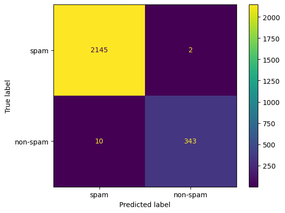

```python
from sklearn.metrics import confusion_matrix, ConfusionMatrixDisplay #This must be given in the report as well
cm = confusion_matrix(test['Predicted_Class_Label'], predicted_test,labels=[1,0])

print(cm)
disp = ConfusionMatrixDisplay(confusion_matrix=cm, display_labels=['spam','non-spam'])
disp.plot()
```

Results: The confusion matrix proves that the true positives are 2145, false negatives are 2, false positives are 10, and true negatives as 343. It correctly identified 2145 positive instances, 343 negative instances, 2 instances that are positive even though they are stated as negative, and 10 instances that are negative but stated as positive.

To see the ROC

```
(array([0.        , 0.99728261, 1.        ]), array([0.        , 0.99953096, 1.        ]), array([inf,  1.,  0.]))
```

```
<sklearn.metrics._plot.roc_curve.RocCurveDisplay at 0x7be56ef39ba0>
```

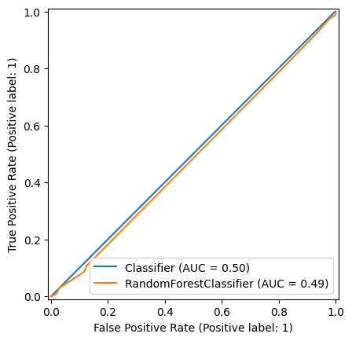

```python
from sklearn.ensemble import RandomForestClassifier
from sklearn.metrics import roc_curve, auc, RocCurveDisplay
import matplotlib.pyplot as plt
from sklearn.ensemble import RandomForestClassifier

X_train, X_test, y_train, y_test, = train_test_split(X,y, test_size = 0.50, shuffle=False, random_state=1)

X = df1.drop(columns=['Predicted_Class_Label'])
y= df1['Predicted_Class_Label']

Y_test_predicted = rf.predict(X_test)
Y_test = rf.predict_proba(X_test)[:,1]

rf = RandomForestClassifier(n_estimators=100, max_depth=11, min_samples_split=8, random_state=1)
rf.fit(X_train, y_train)
auc=roc_curve(y_test, Y_test_predicted)
print(auc)
fig, ax = plt.subplots()
RocCurveDisplay.from_predictions(y_test, Y_test_predicted, pos_label=1, ax=ax)
RocCurveDisplay.from_estimator(rf, X_test, y_test, pos_label=1, ax=ax)
```

Results: The AUC score is .50, proving that the model has a 50% probability of correctly ranking the project's random positive and negative instances. This is not a good score which can affect our confusion matrix.

F1 score

```python
#F1
from sklearn.metrics import f1_score

#creating the connection between the random forest classifier
model_1 = rf
y_train_pred = model_1.predict(X_train)
y_test_pred = model_1.predict(X_test)

train_f1 = f1_score(y_train, y_train_pred)
test_f1 = f1_score(y_test, y_test_pred)

print(f"Training F1 Score: {train_f1:.4f}")
print(f"Testing F1 Score: {test_f1:.4f}")
```

```
Training F1 Score: 0.9226
Testing F1 Score: 0.9206
```

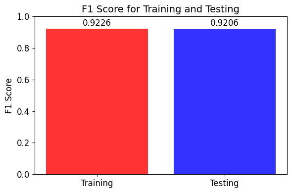

```python
import matplotlib.pyplot as plt

#Ploting for the F1 Score
categories = ['Training', 'Testing']
f1_scores = [train_f1, test_f1]

# Create the bar plot
plt.figure(figsize=(6, 4))
plt.bar(categories, f1_scores, color=['red', 'blue'], alpha=0.8)
plt.ylim(0, 1)
plt.title('F1 Score for Training and Testing', fontsize=14)
plt.ylabel('F1 Score', fontsize=12)
plt.xticks(fontsize=12)
plt.yticks(fontsize=12)

y_train_pred = model_1.predict(X_train)
y_test_pred = model_1.predict(X_test)

train_f1 = f1_score(y_train, y_train_pred)
test_f1 = f1_score(y_test, y_test_pred)

for i, score in enumerate(f1_scores):
    plt.text(i, score + 0.02, f"{score:.4f}", ha='center', fontsize=12)

plt.tight_layout()
plt.show()
```

Results: The F1 score for the training and testing dataset is too high which can highlight our issues with our model. Our model can detect certain thresholds but cannot identify thresholds in a larger range. It can only be used to highlight specific datasets

Type 1 and Type 2 Errors

Type 1: fp / (fp + tn)

Type 2: fn / (fn + tp)

Explain whether your model performs well in predicting legitimate or phishing websites. No our model does not predict legitmate or phishing websites well because of the AUC score. The AUC score was .50 which can lead to a lot of false postives.

## Part B

In this phase, you will use your trained model to predict the cases in the training set. Note that your need to upload test cases as a different dataframe and export your predictions as a CVS file. Here are important points.

Make sure that you are implementing the same normalization and standardization procedures on the testing set as well. You must use the same features and they must be introduced to the algorithm in the same order. Important: When you export your predictions as a CSV file, you should have two columns in your CVS file as follows: Id Prediction

```python
extracted_df = pd.DataFrame({
       "id": df1.index,
       "Prediction": predictions
   })

extracted_file_path = "final.csv"
extracted_df.to_csv(extracted_file_path, index=False)

from google.colab import files
files.download(extracted_file_path)
```

# 1.Important characteristics of a phishing website

# 2.Explanation for an Upper-Tier Manager

Based on the previous explanations of the model that was used and the scores that we received from the model it provides insight that our model may not be suffice but has the potential to identify websites being legitimate or illegitimate. There needs to be more calibration on the SVM side and the Decision Tree classifier. It might be low, but the 50% AUC score can help us determine if smaller sections of data are legitimate or illegitimate. When comparing the CSV file with other ones it can be used to determine which model is more successful than the other.

This is of importance because identifying phishing websites enhances cybersecurity, protects user data, builds trust, and enables proactive defense against attacks. Automated tools and machine learning improve scalability and compliance with data protection regulations. However, challenges include false positives, resource intensity, evolving phishing tactics, and potential privacy concerns. Effective protection requires a layered approach, combining automated systems, user education, and constant updates to detection models. Balancing security with usability and fostering collaboration among stakeholders are key to mitigating phishing risks.

See below: Our low AUC model can be used as a reference for a better model to see if the other is more successful than the other one.

The training model below had a high AUC score calculated in comparison to the AUC score obtained from the testing set

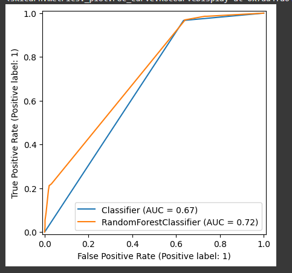

AUC Score from Test:

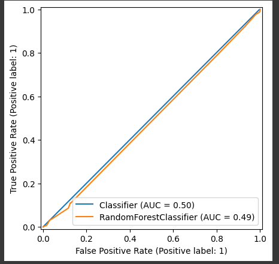